# Distribución Hipergeométrica

Téllez Gerardo Rubén

3/2/2022

## V.A

Consideremos el experimento “extraer a la vez (o una detrás de otra, sin retornarlos) $n$ objetos donde hay $N$ de tipo A, y $M$ de tipo B”. Si $X$ es una variable aleatoria que mide el “número de objetos del tipo A”, diremos que $X$ se distribuye como una Hipergeométrica con parámetros $N,\ M,\ n$

$$X \sim H(N, M, n)$$

- El **dominio** de la función será $D_X = \{0, 1, 2,\ -n \}$ (en general)
- La **función de densidad** vendrá dada por

$$f(k) = \frac{{N \choose k} \times {M \choose n-k}}{{N+M \choose n}}$$

Tenemos objetos de dos tipos y sacamos objetos y no los regresamos.

Parte de la regla de Laplace.

- La función de distribución vendrá dada por

$$F(X) = \Bigg \{ \begin{matrix} 0 & si\ x < 0 \\ \sum_{k=0}^{x} & si\ 0 \le x < n \\ 1 & si\ x \ge n \end{matrix}$$

- Esperanza $E(X) = \frac{nN}{N + M}$
- Varianza $Var(X) = \frac{nNM}{(N+M)^2} \times \frac{N + M - n}{N + M -1}$

n = total de objetos extraídos N = objetos de tipo A M = objetos de tipo B

## Ejemplo

Supongamos que tenemos 20 animales, de los cuales 7 son perros, y el resto no son perros. Queremos medir, la probabilidad de encontrar un número determinado de perros si elegimos $x = 12$ animales al azar.

## En R

```r
M = 7
N = 13
x = 12

dhyper(x = 0:12, m = M, n = N, k = x)
```

```
##  [1] 0.0001031992 0.0043343653 0.0476780186 0.1986584107 0.3575851393
##  [6] 0.2860681115 0.0953560372 0.0102167183 0.0000000000 0.0000000000
## [11] 0.0000000000 0.0000000000 0.0000000000
```

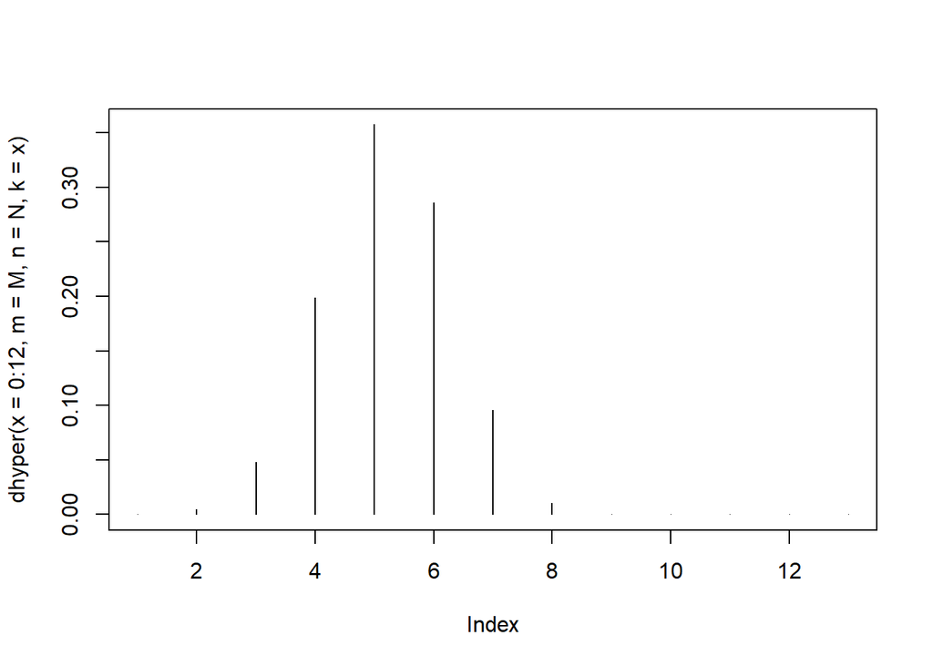

```r
# Probabilidad de que salga un perro, de que salgan 2 perros, de que salgan3 perros...
#de que salgan k perros. Es imposible que salgan más perros de los que hay.

plot(dhyper(x = 0:12, m = M, n = N, k = x), type="h")
```

```r
phyper(q = 0:12, m = M, n = N, k = x)
```

```
##  [1] 0.0001031992 0.0044375645 0.0521155831 0.2507739938 0.6083591331
##  [6] 0.8944272446 0.9897832817 1.0000000000 1.0000000000 1.0000000000
## [11] 1.0000000000 1.0000000000 1.0000000000
```

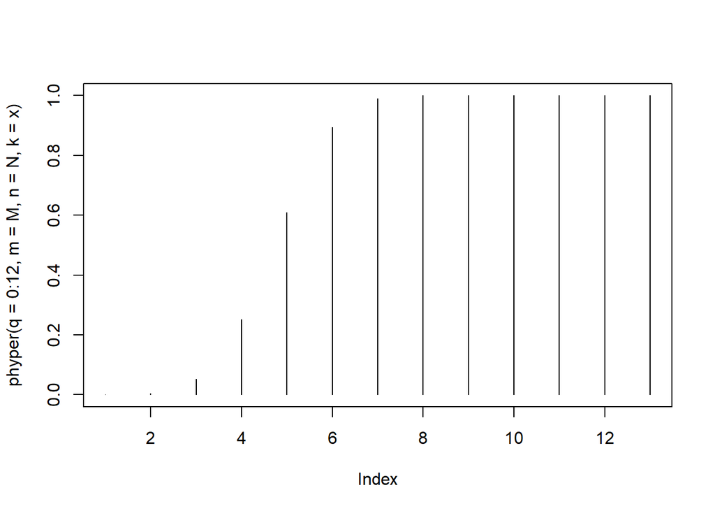

```r
# Probabilidad acumulada de que salgan x o menos perros
plot(phyper(q = 0:12, m = M, n = N, k = x), type="h")
```

```r
qhyper(p = 0.5, m=M, n=N, k=x) #Mediana
```

```
## [1] 4
```

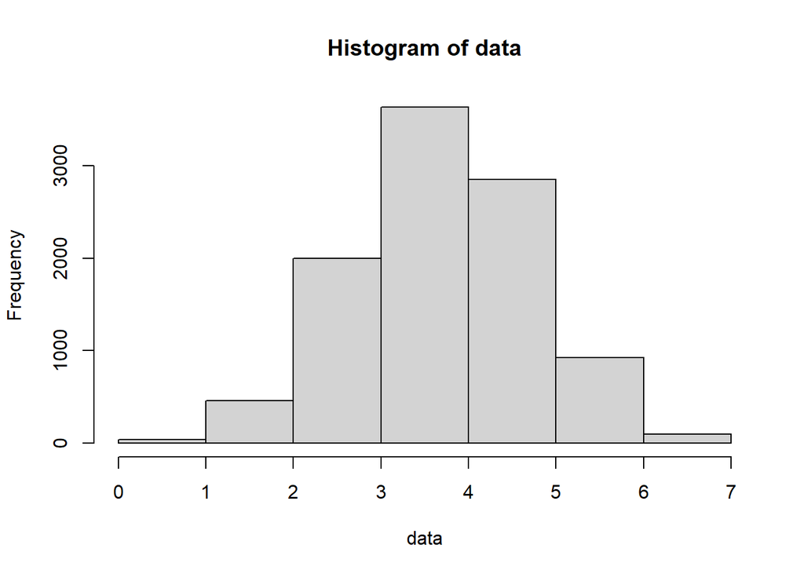

```r
data=rhyper(nn = 10000, m = M, n = N, k = x)
hist(data, breaks=8)
```

## En Python

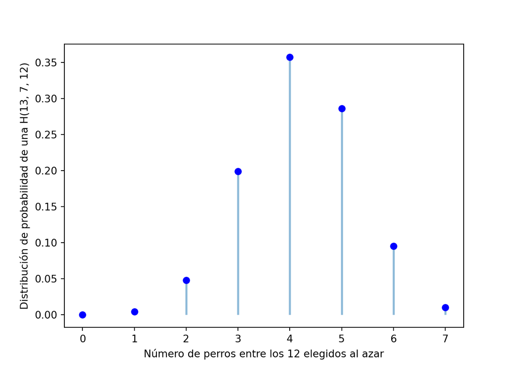

```python
from scipy.stats import hypergeom
import matplotlib.pyplot as plt
import numpy as np

[M, n, N] = [20, 7, 12] #De 20, se extraen 12, 7 son de los que quiero

rv = hypergeom(M, n, N)
x = np.arange(n+1)
y = rv.pmf(x)

fig = plt.figure()
ax = fig.add_subplot(111)
ax.plot(x, y, "bo")
ax.vlines(x, 0, y, lw=2, alpha = 0.5)
ax.set_xlabel("Número de perros entre los 12 elegidos al azar")
ax.set_ylabel("Distribución de probabilidad de una H(13, 7, 12)")
plt.show()
```

```python
mean, var, skew, kurt = rv.stats(moments="mvsk")

print("Media:", mean)
```

```
## Media: 4.199999999999999
```

```python
print("Varianza:", var)
```

```
## Varianza: 1.1494736842105264
```

```python
print("Sesgo:", skew)
```

```
## Sesgo: -0.06218121795609882
```

```python
print("Curtosis:", kurt)
```

```
## Curtosis: -0.15266106442577032
```